# 14. GAMLSS - zastosowania

Michał Maj

2021-05-23

# 1 Uogólnione modele addytywne z parametrami położenia skali i kształtu - GAMLSS

## 1.1 Model liniowy z heteroskedastycznością

Na poprzenich zajęciach rozważaliśmy model liniowy modelujący zależność miedzy wiekiem pacjenta, a ciśnieniem rozkurczowym:

$$DIA|AGE \sim N(\mu, \sigma^2)\\
\mu = \beta_0 + \beta_1 AGE$$

gdzie $DIA$ oznacza ciśnienie rozkurczowe, a $AGE$ oznacza wiek pacjenta.

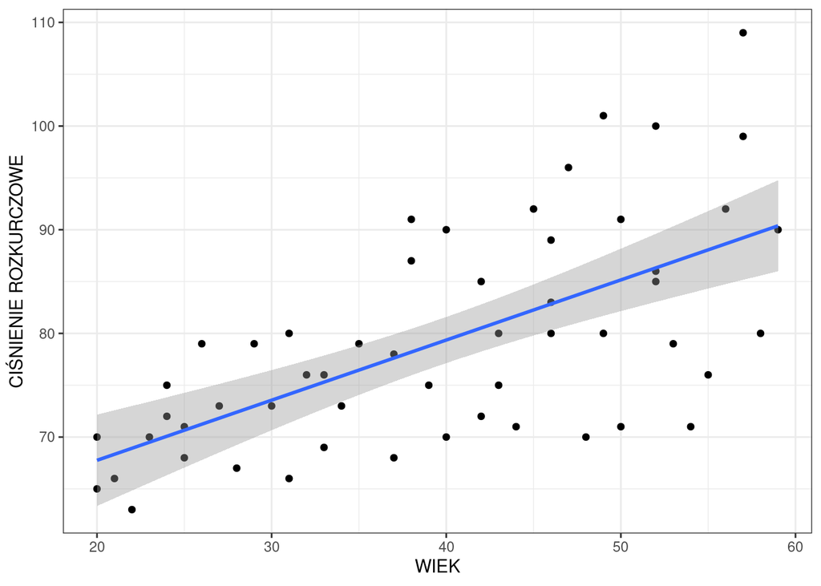

```r
blood <- read_csv2("blood.csv")
ggplot(blood, aes(age, diast)) + theme_bw() + geom_point() +
  xlab("WIEK") + ylab("CIŚNIENIE ROZKURCZOWE") +
  stat_smooth(method = "lm", se = TRUE)
```

W modelu tym występuje **heteroskedastyczność**, czyli niestałość wariancji. Oznacza to, że zalożenia powyższego modelu nie są spełnione. Jako alternatywę rozpatrzmy model:

$$DIA|AGE \sim N(\mu, \sigma^2)\\
\mu = \beta_{01} + \beta_{11} AGE\\
\sigma = \beta_{02} + \beta_{12} AGE$$

Poza wartością oczekiwaną chcemy także zamodelować odchylenie standardowe w naszym modelu, czyli mamy tu do czynienia z modelem rodziny $GAMLSS$. Podstawową funkcją w pakiecie `gamlss` jest funkcja `gamlss`, która odpowiada za tworzenie i dopasowanie modelu statystycznego. Aby do naszego modelu dodać równanie modelujące odchylenie standardowe musimy użyć argumentu `sigma.formula`. Porównajmy klasyczny model liniowy z modelem ze zmienną wariancją:

```r
blood_lm <- gamlss(formula = diast ~ age, data = blood, family = NO(sigma.link = "identity"))
```

```
## GAMLSS-RS iteration 1: Global Deviance = 377.7369
## GAMLSS-RS iteration 2: Global Deviance = 377.7369
```

```r
blood_lm_het <- gamlss(formula = diast ~ age, sigma.formula = ~ age, data = blood, family = NO(sigma.link = "identity"))
```

```
## GAMLSS-RS iteration 1: Global Deviance = 362.5672
## GAMLSS-RS iteration 2: Global Deviance = 362.5003
## GAMLSS-RS iteration 3: Global Deviance = 362.5002
```

Podsumowanie modelu liniowego daje nam te same wyniki co funkcja `lm`:

```r
summary(blood_lm)
```

```
## Family:  c("NO", "Normal")
##
## Call:  gamlss(formula = diast ~ age, family = NO(sigma.link = "identity"),
##     data = blood)
##
## Fitting method: RS()
##
## ------------------------------------------------------------------
## Mu link function:  identity
## Mu Coefficients:
##             Estimate Std. Error t value Pr(>|t|)
## (Intercept) 56.15693    3.91902  14.329  < 2e-16 ***
## age          0.58003    0.09514   6.097 1.45e-07 ***
## ---
## Signif. codes:  0 '***' 0.001 '**' 0.01 '*' 0.05 '.' 0.1 ' ' 1
##
## ------------------------------------------------------------------
## Sigma link function:  identity
## Sigma Coefficients:
##             Estimate Std. Error t value Pr(>|t|)
## (Intercept)   7.9935     0.7692   10.39 3.42e-14 ***
## ---
## Signif. codes:  0 '***' 0.001 '**' 0.01 '*' 0.05 '.' 0.1 ' ' 1
##
## ------------------------------------------------------------------
## No. of observations in the fit:  54
## Degrees of Freedom for the fit:  3
##       Residual Deg. of Freedom:  51
##                       at cycle:  2
##
## Global Deviance:     377.7369
##             AIC:     383.7369
##             SBC:     389.7039
```

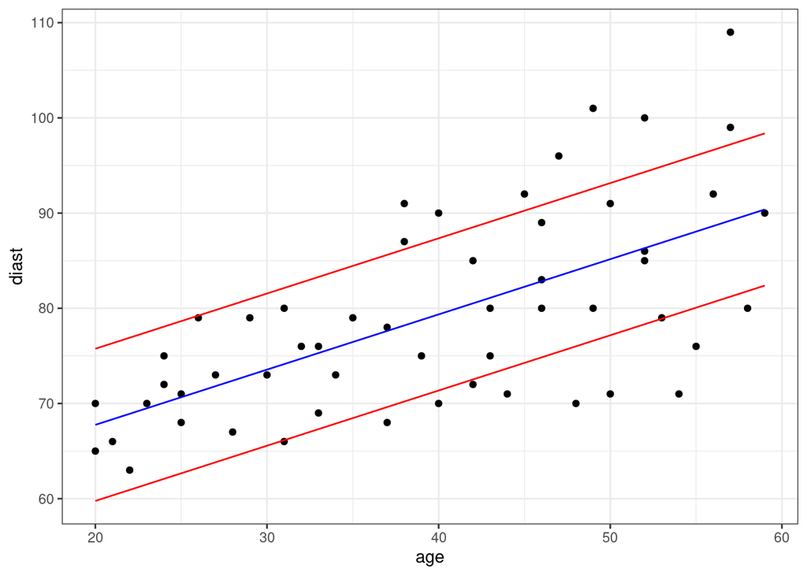

```r
blood <- blood %>%
  mutate(
    model_lm_pred = fitted(blood_lm, "mu"),
    model_lm_pred_sigma = fitted(blood_lm, "sigma")
  )
ggplot(blood, aes(x = age, y = diast)) + geom_point() + theme_bw() +
  geom_line(aes(y = model_lm_pred), color = "blue") +
  geom_line(aes(y = model_lm_pred + model_lm_pred_sigma), color = "red") +
  geom_line(aes(y = model_lm_pred - model_lm_pred_sigma), color = "red")
```

Sprawdźmy teraz jak wygląda model z heteroskedastycznością:

```r
summary(blood_lm_het)
```

```
## Family:  c("NO", "Normal")
##
## Call:  gamlss(formula = diast ~ age, sigma.formula = ~age,
##     family = NO(sigma.link = "identity"), data = blood)
##
## Fitting method: RS()
##
## ------------------------------------------------------------------
## Mu link function:  identity
## Mu Coefficients:
##             Estimate Std. Error t value Pr(>|t|)
## (Intercept) 55.53192    2.46890  22.493  < 2e-16 ***
## age          0.59732    0.07811   7.647 5.86e-10 ***
## ---
## Signif. codes:  0 '***' 0.001 '**' 0.01 '*' 0.05 '.' 0.1 ' ' 1
##
## ------------------------------------------------------------------
## Sigma link function:  identity
## Sigma Coefficients:
##             Estimate Std. Error t value Pr(>|t|)
## (Intercept) -2.03663    1.75867  -1.158    0.252
## age          0.24141    0.05557   4.345 6.82e-05 ***
## ---
## Signif. codes:  0 '***' 0.001 '**' 0.01 '*' 0.05 '.' 0.1 ' ' 1
##
## ------------------------------------------------------------------
## No. of observations in the fit:  54
## Degrees of Freedom for the fit:  4
##       Residual Deg. of Freedom:  50
##                       at cycle:  3
##
## Global Deviance:     362.5002
##             AIC:     370.5002
##             SBC:     378.4562
```

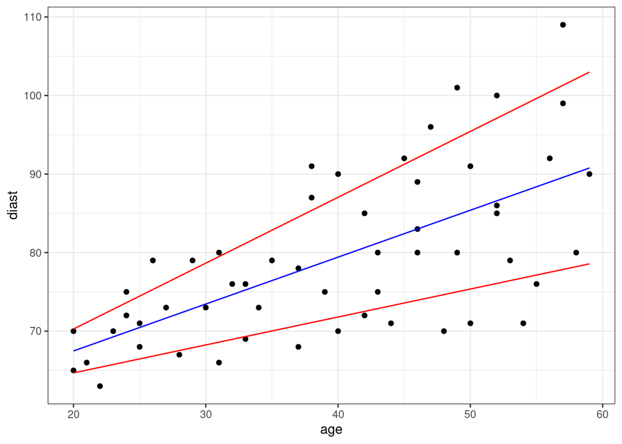

```r
blood <- blood %>%
  mutate(
    model_lm_het_pred = fitted(blood_lm_het, "mu"),
    model_lm_het_pred_sigma = fitted(blood_lm_het, "sigma")
  )
ggplot(blood, aes(x = age, y = diast)) + geom_point() + theme_bw() +
  geom_line(aes(y = model_lm_het_pred), color = "blue") +
  geom_line(aes(y = model_lm_het_pred + model_lm_het_pred_sigma), color = "red") +
  geom_line(aes(y = model_lm_het_pred - model_lm_het_pred_sigma), color = "red")
```

Porównanie modeli mozemy przeprowadzić a pomocą np. krytermium AIC lub R-squared:

```r
Rsq(blood_lm)
```

```
## [1] 0.4076966
```

```r
Rsq(blood_lm_het)
```

```
## [1] 0.5533131
```

```r
AIC(blood_lm, blood_lm_het)
```

```
##              df      AIC
## blood_lm_het  4 370.5002
## blood_lm      3 383.7369
```

## 1.2 Od modelu liniowego do modelu GAMLSS

Zacznijmy od zbadania rozkładów zmiennych:

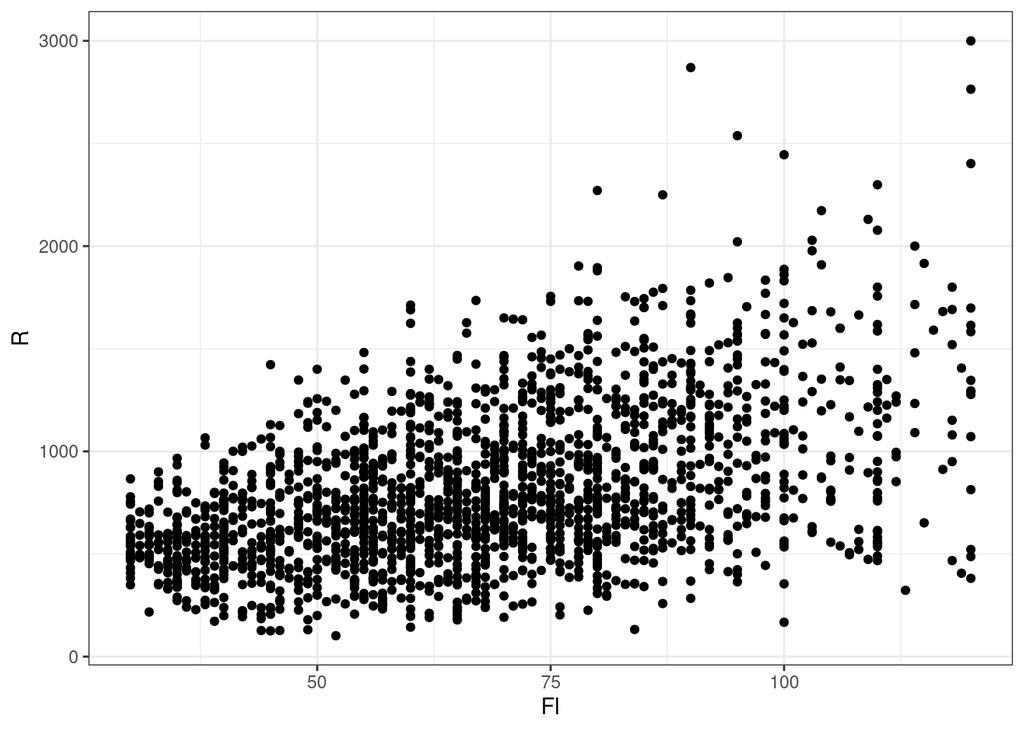

```r
data("rent")
ggplot(rent, aes(x = Fl, y = R)) + geom_point() + theme_bw()
```

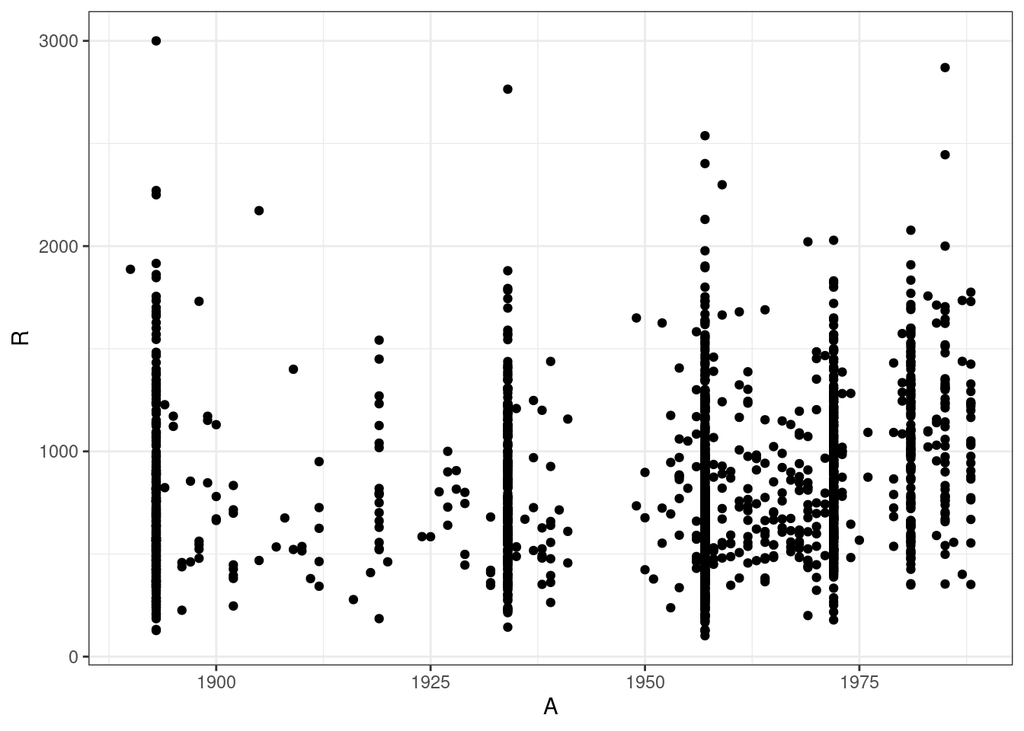

```r
ggplot(rent, aes(x = A, y = R)) + geom_point() + theme_bw()
```

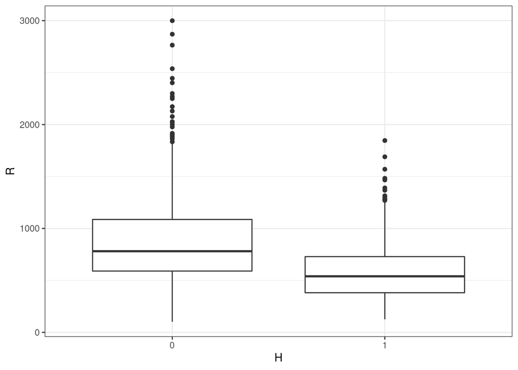

```r
ggplot(rent, aes(x = H, y = R)) + geom_boxplot() + theme_bw()
```

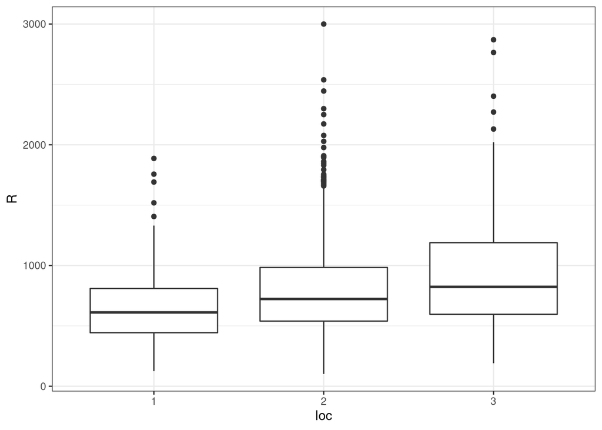

```r
ggplot(rent, aes(x = loc, y = R)) + geom_boxplot() + theme_bw()
```

Pierwszy wykres ukazyjący wozkład czynszu względem pola powierzchni mieszkania sugeruje relację rosnącą (dodatnia korelacja), ze zwiększoną wariancją dla dużych powierzchni mieszkaniowych (czyli brak stałości wariancji). Istnieją również pewne oznaki (do przetestowania) prawostronnej skośności rozkładu czynszu.

Specyfika rozkładu czynszu na tle roku budowy, wynika z metody zbierania danych. Wiele obserwacji roku budowy zebrane zostało w skali interwałowej, a nastepnie uśrednione do srodka danego przedziału. Wykres ten sugeruje, że w przypadku mieszkań do 1960 r. średni czynsz jest mniej więcej stały, ale w przypadku mieszkań wybudowanych po tym roku mediana czynszu rośnie.

Dwa wykresy pudełkowe pokazują, jak zmienia się czynsz w zależności od zmiennych kategorycznych. Mediana czynszu rośnie, jeśli mieszkanie jest wyposażone w centralne ogrzewanie, a także wraz ze zmianą lokalizacji (poniżej średniej do średniej, a następnie powyżej średniej). Nie ma tu niespodzianek w, ale znowu problem skośności jest wyraźny, z asymetrycznymi pudełkami od mediany i dłuższym górnym niż dolnym wąsie.

Podsumowując, model statystyczny powinien sobie radzić z problemami:

1. Złożoność relacji między predyktorami a zmienną objaśnianą - najprawdopodobniej jest nieliniowa.
2. Niestałość wariancji zmiennej objaśnianej.
3. Skośność w rozkładzie zmiennej objaśnianej.

Póki co zaczniemy od modelu standardowej regresji liniowej i będziemy go rozwijać:

```r
r1 <- gamlss(formula = R ~ Fl + A + H + loc, family = NO, data = rent, trace = FALSE)
```

Dopsaowany model wygląda nastepująco:

$$\hat{\mu}=-2775.04 + 8.84 Fl + 1.48 A -204.76(H=1)+134.05(loc=2)+ 209.58(loc=3) \\ \\
\log (\hat{\sigma})= 5.73165$$

Zauważmy, że $\sigma$ modelowane jest przy użyciu logarytmicznej **funkcji łączącej**. Sprawdźmy dopasowanie naszego modelu:

```r
Rsq(r1)
```

```
## [1] 0.3372028
```

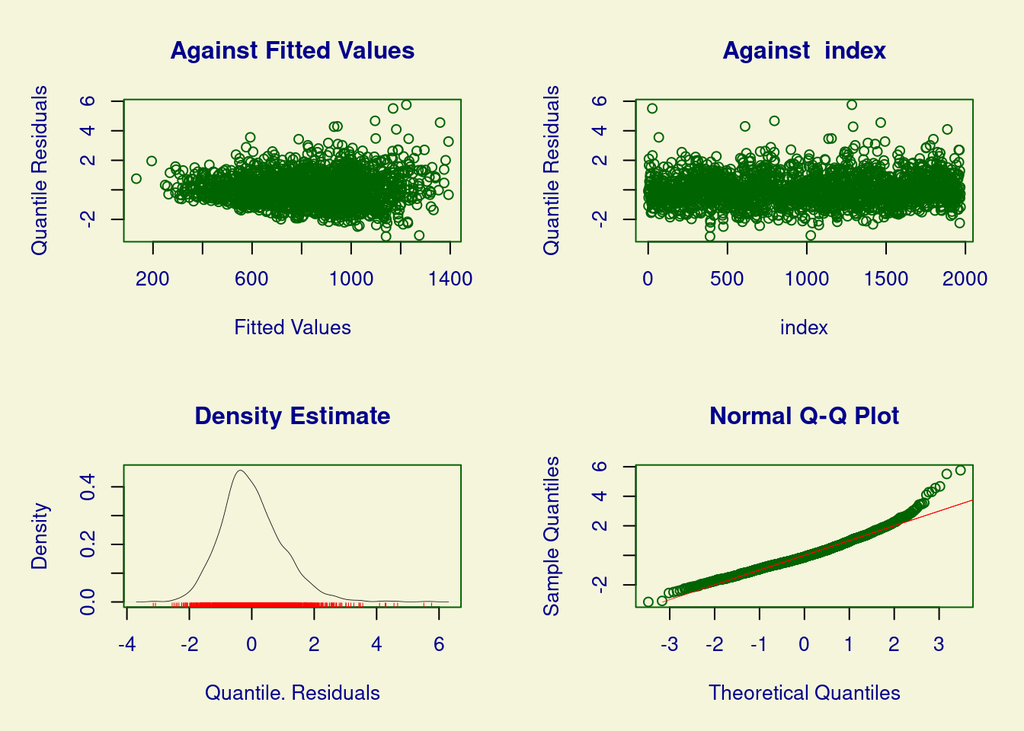

```
##        Summary of the Quantile Residuals
##                            mean   =  4.959556e-13
##                        variance   =  1.000508
##                coef. of skewness  =  0.7470097
##                coef. of kurtosis  =  4.844416
## Filliben correlation coefficient  =  0.9859819
```

```r
plot(r1)
```

Założenia o normalności modelu można łatwo odrzucic patrząc na **Q-Q plot** (widać odejście od zależności liniowej między uporządkowanymi zaobserwowanymi znormalizowaymi kwantylami reszt i ich przybliżonymi wartościami oczekiwanymi), co sugeruje pozytywną skośność rozkładu.

Dodatkowo wykres nr 1. (reszty vs wartości dopasowane) nie jest jednostajnie rozrzucowny wokół $0$ co może sugerować heteroskedastyczność.

Zauważmy dodatkowo, ze czynasz może przyjmować tylko i wyłącznie wartości dodatkie, co oznacza, że powinniśmy dostosować nasz rozkład.

Zmienimy więc nasz model z regresji liniowej na GLM z rozkładem Gamma.

$$R|X \sim Gamma(\mu, \sigma^2)\\
log(\mu) = \beta_1 X\\
log(\sigma) = \beta_2$$

w `gamlss` rozkład gamma ma następujacą parametryzację dla $\sigma$:

$$\sigma=\sqrt{\phi}$$
gdzie $\phi$ jest **paraetrem dyspersji**.

```r
r2 <- gamlss(formula = R ~ Fl + A + H + loc, family = GA, data = rent, trace = FALSE)
summary(r2)
```

```
## Family:  c("GA", "Gamma")
##
## Call:  gamlss(formula = R ~ Fl + A + H + loc, family = GA,
##     data = rent, trace = FALSE)
##
## Fitting method: RS()
##
## ------------------------------------------------------------------
## Mu link function:  log
## Mu Coefficients:
##               Estimate Std. Error t value Pr(>|t|)
## (Intercept)  2.8649770  0.5681265   5.043 5.01e-07 ***
## Fl           0.0106232  0.0004128  25.735  < 2e-16 ***
## A            0.0015100  0.0002886   5.232 1.86e-07 ***
## H1          -0.3000745  0.0231141 -12.982  < 2e-16 ***
## loc2         0.1907641  0.0305197   6.251 5.00e-10 ***
## loc3         0.2640828  0.0329216   8.022 1.78e-15 ***
## ---
## Signif. codes:  0 '***' 0.001 '**' 0.01 '*' 0.05 '.' 0.1 ' ' 1
##
## ------------------------------------------------------------------
## Sigma link function:  log
## Sigma Coefficients:
##             Estimate Std. Error t value Pr(>|t|)
## (Intercept) -0.98220    0.01558  -63.05   <2e-16 ***
## ---
## Signif. codes:  0 '***' 0.001 '**' 0.01 '*' 0.05 '.' 0.1 ' ' 1
##
## ------------------------------------------------------------------
## No. of observations in the fit:  1969
## Degrees of Freedom for the fit:  7
##       Residual Deg. of Freedom:  1962
##                       at cycle:  2
##
## Global Deviance:     27764.59
##             AIC:     27778.59
##             SBC:     27817.69
```

Dopsaowany model wygląda nastepująco:

$$\log (\hat{\mu})= 2.865 + 0.0106 Fl + 0.00151 A -0.3(H=1)+0.191(loc=2)+ 0.264(loc=3) \\ \\
\log(\hat{\sigma})= -0.9822$$

Kolejnym pasującym rozkładem moze być **Inverse-Gamma**.

```r
r22 <- gamlss(formula = R ~ Fl + A + H + loc, family = IG, data = rent, trace = FALSE)
```

Wszystkie 3 modele mają tą samą liczbę parametrów dlatego możemy je porównać uogólnionym kryterium AIC:

```r
GAIC(r1, r2, r22, k = 0)
```

```
##     df      AIC
## r2   7 27764.59
## r22  7 27991.56
## r1   7 28159.00
```

Wyglada na to, że rozkład Gamma daje najlepsze dopasowanie. Zobaczmy teraz wykresy dopasowania modelu:

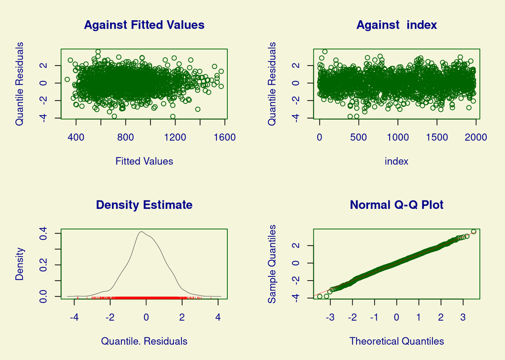

```
##        Summary of the Quantile Residuals
##                            mean   =  0.0004795675
##                        variance   =  1.000657
##                coef. of skewness  =  -0.1079453
##                coef. of kurtosis  =  3.255464
## Filliben correlation coefficient  =  0.9990857
```

```r
plot(r2)
```

Problemy, które mieliśmy do tej pory zostały częściowo rozwiązane, jednakże mozemty teraz wprowadzić nieliniowość do anszego modelu i zobaczyć czy poprawi to wyniki.

```r
r3 <- gamlss(R ~ pb(Fl) + pb(A) + H + loc, family = GA, data = rent, trace = FALSE)
AIC(r2, r3)
```

```
##          df      AIC
## r3 11.21547 27705.65
## r2  7.00000 27778.59
```

```r
summary(r3)
```

```
## Family:  c("GA", "Gamma")
##
## Call:  gamlss(formula = R ~ pb(Fl) + pb(A) + H + loc, family = GA,
##     data = rent, trace = FALSE)
##
## Fitting method: RS()
##
## ------------------------------------------------------------------
## Mu link function:  log
## Mu Coefficients:
##               Estimate Std. Error t value Pr(>|t|)
## (Intercept)  3.0851197  0.5691903   5.420 6.69e-08 ***
## pb(Fl)       0.0103084  0.0004031  25.574  < 2e-16 ***
## pb(A)        0.0014062  0.0002892   4.862 1.26e-06 ***
## H1          -0.3008111  0.0225874 -13.318  < 2e-16 ***
## loc2         0.1886692  0.0299282   6.304 3.57e-10 ***
## loc3         0.2719856  0.0322843   8.425  < 2e-16 ***
## ---
## Signif. codes:  0 '***' 0.001 '**' 0.01 '*' 0.05 '.' 0.1 ' ' 1
##
## ------------------------------------------------------------------
## Sigma link function:  log
## Sigma Coefficients:
##             Estimate Std. Error t value Pr(>|t|)
## (Intercept) -1.00196    0.01559  -64.27   <2e-16 ***
## ---
## Signif. codes:  0 '***' 0.001 '**' 0.01 '*' 0.05 '.' 0.1 ' ' 1
##
## ------------------------------------------------------------------
## NOTE: Additive smoothing terms exist in the formulas:
##  i) Std. Error for smoothers are for the linear effect only.
## ii) Std. Error for the linear terms maybe are not accurate.
## ------------------------------------------------------------------
## No. of observations in the fit:  1969
## Degrees of Freedom for the fit:  11.21547
##       Residual Deg. of Freedom:  1957.785
##                       at cycle:  3
##
## Global Deviance:     27683.22
##             AIC:     27705.65
##             SBC:     27768.29
```

Wygląda na to, że GAM z **P-splajnami** jest nieco lepszy niż GLM, jednakże powinniśmy wykonać dokładniszy test dla estymatorów nieliniowych. Możemy to zrobić przy pomocy funkcji `drop1`:

```r
drop1(r3)
```

```
## Single term deletions for
## mu
##
## Model:
## R ~ pb(Fl) + pb(A) + H + loc
##            Df   AIC    LRT   Pr(Chi)
## <none>        27706
## pb(Fl) 1.4680 28261 558.59 < 2.2e-16 ***
## pb(A)  4.3149 27798 101.14 < 2.2e-16 ***
## H      1.8445 27862 160.39 < 2.2e-16 ***
## loc    2.0346 27770  68.02 1.825e-15 ***
## ---
## Signif. codes:  0 '***' 0.001 '**' 0.01 '*' 0.05 '.' 0.1 ' ' 1
```

Jak widać wszystkie zmienne są istotne. Możemy także zwizualizować dopasowanie zmiennych naszego modelu:

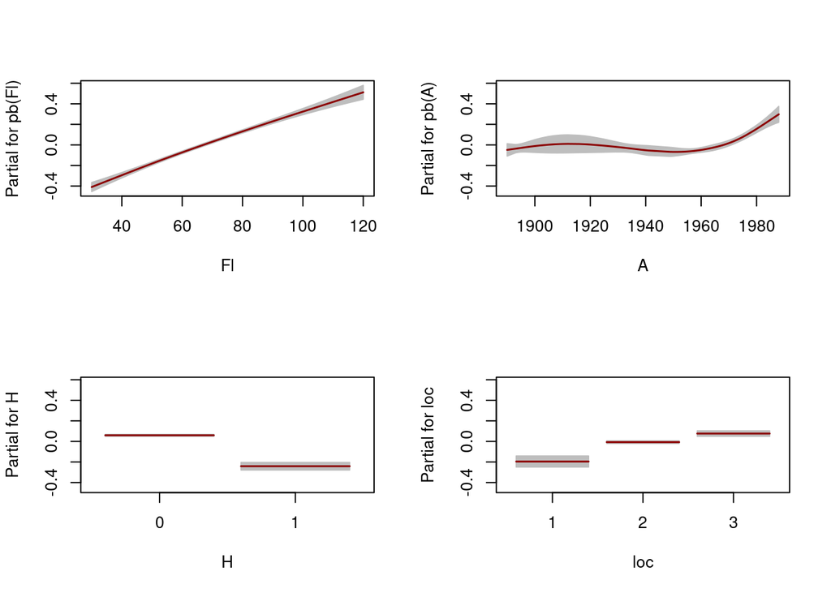

```r
term.plot(r3, pages = 1, ask = FALSE)
```

Widać, że wielkość czynszu zmienia się praktycznie liniowo względem pola powierzchni, a bardzo nieliniowo względem roku budowy. Dopasowanie modelu GAM możemy sprawdzić używająć **Worm plot** (QQ-plot dla reszt pozbawionych trendu):

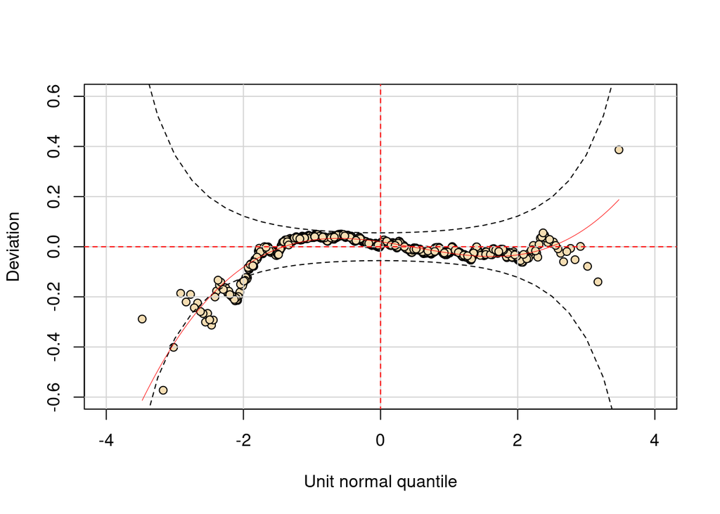

```r
wp(r3, ylim.all = .6)
```

W kolejnym kroku do modelu GAM dodamy modelowanie odchylenia standardowego:

```r
r4 <- gamlss(R ~ pb(Fl) + pb(A) + H + loc, sigma.fo = ~ pb(Fl) + pb(A) + H + loc, family = GA, data = rent, trace = FALSE)
r5 <- gamlss(R ~ pb(Fl) + pb(A) + H + loc, sigma.fo = ~ pb(Fl) + pb(A) + H + loc, family = IG, data = rent, trace = FALSE)
AIC(r3, r4, r5)
```

```
##          df      AIC
## r4 22.25035 27614.78
## r3 11.21547 27705.65
## r5 21.82318 27716.66
```

Ponownie najlepszy okazuje się model z rozkładem Gamma. Sprawdźmy jak wygląda dopasowanie predyktorów i ich istotność dla odchylenia standardowego:

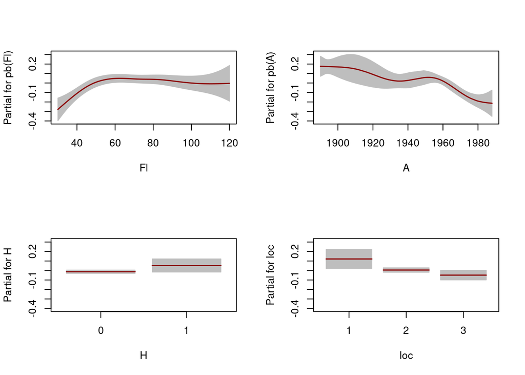

```r
term.plot(r4, pages = 1, what = "sigma", ask = FALSE)
```

```r
drop1(r4, what = "sigma")
```

```
## Single term deletions for
## sigma
##
## Model:
## ~pb(Fl) + pb(A) + H + loc
##             Df   AIC    LRT   Pr(Chi)
## <none>         27615
## pb(Fl) 4.02694 27631 24.683 5.997e-05 ***
## pb(A)  3.87807 27659 52.167 1.067e-10 ***
## H      0.88335 27615  1.866   0.14788
## loc    2.03694 27619  8.036   0.01872 *
## ---
## Signif. codes:  0 '***' 0.001 '**' 0.01 '*' 0.05 '.' 0.1 ' ' 1
```

Jak widzimy centralne ogrzewanie nie ma wpływu na odchylenie standardowe.

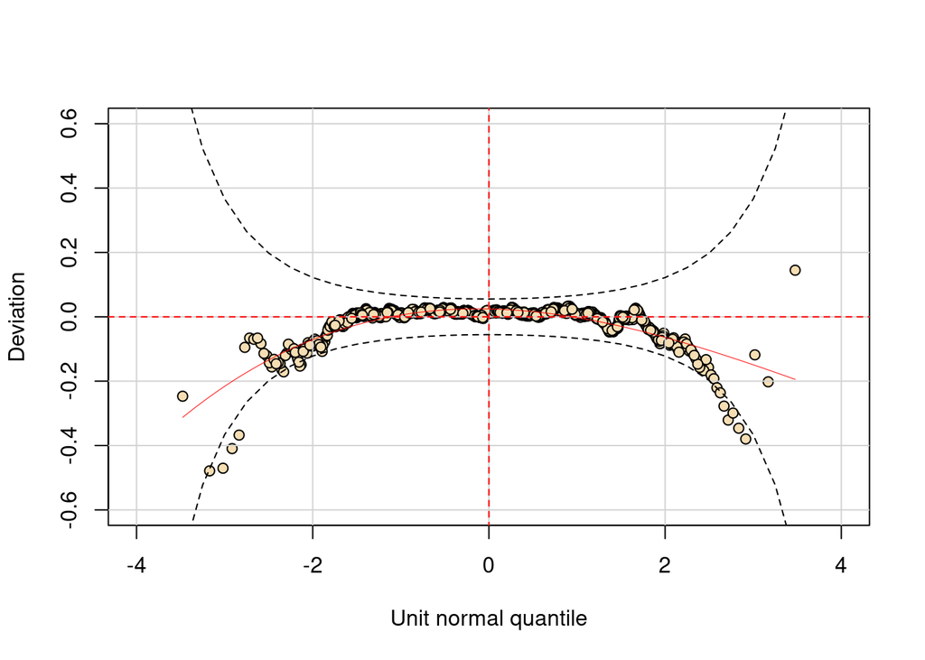

```r
wp(r4, ylim.all = .6)
```

Kolejnym krokiem będzie zamodelowanie skośności. Musimy jednak odejść od rozkładu Gamma i wybrać jakiś gdzie skośność można zamodelować. użyjemy rozkładu **BCCGo** (Box-Cox Cole and Green):

```r
r6 <- gamlss(R ~ pb(Fl) + pb(A) + H +  loc,
             sigma.fo = ~ pb(Fl) + pb(A) + H + loc,
             nu.fo = ~ 1,
             family = BCCGo, data = rent , trace = FALSE)
r7 <- gamlss(R ~ pb(Fl) + pb(A) + H +  loc,
             sigma.fo = ~ pb(Fl) + pb(A) + H + loc,
             nu.fo = ~ pb(Fl) + pb(A) + H + loc,
             family = BCCGo , data = rent , trace = FALSE)
AIC(r4, r6, r7)
```

```
##          df      AIC
## r7 28.41391 27608.15
## r6 22.48092 27611.02
## r4 22.25035 27614.78
```

Kryterium AIC mówi, że dopasowanie rozkładem BCCgo jest lepszym rozwiązaniem niz rozkład Gamma:

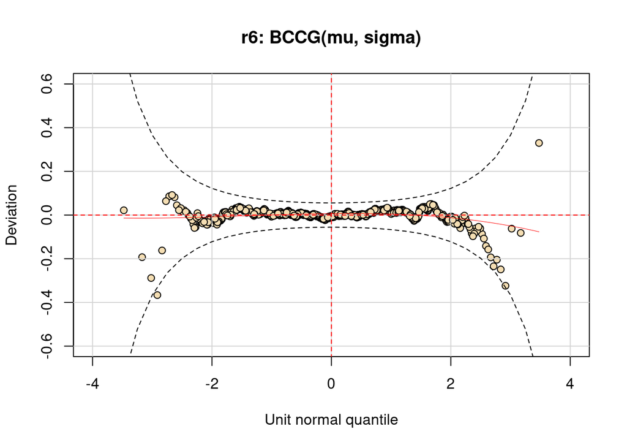

```r
wp(r6, ylim.all = .6); title("r6: BCCG(mu, sigma)")
```

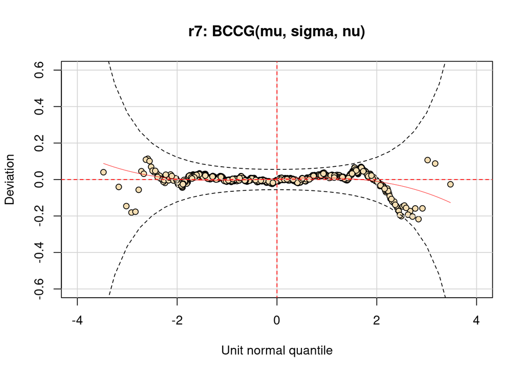

```r
wp(r7, ylim.all = .6); title("r7: BCCG(mu, sigma, nu)")
```